# Applying LDA Topic Models to Analyze Research Abstracts

Author

Julie Nguyen

Welcome to the next phase of my journey to prepare for my comprehensive exams! Here, we delve deeper into the world of Natural Language Processing (NLP) to unearth the thematic foundations of the research papers on my reading list. Having previously refined and analyzed the abstracts of over a hundred papers using TF-IDF and weighted log odds, our focus now shifts to topic modeling—a powerful NLP technique that detects patterns and themes across vast text collections.

Here’s our roadmap for our exploration:

1. Preparation for Topic Modeling: We begin by transforming our cleaned text data from a tidy format, where each word is isolated in its own row, back to a wide format where each document is represented in a single row. This preparation is crucial for topic modeling.
2. Creating a Document-Term Matrix (DTM): We convert the wide-format text data into a document-term matrix. This matrix serves as the input for our topic modeling, enabling the detection of textual patterns.
3. Training Topic Models: Using Latent Dirichlet Allocation (LDA), we train a series of topic models, experimenting with topics ranging from 5 to 130. Our objective is to identify the model that most accurately captures the core themes, assessed by their topic coherence.
4. Evaluating Models: We evaluate the semantic coherence of each model and use visualizations to determine the most effective model.
5. Analyzing Topic Model Results: Once we select our model, we delve into the topics it uncovered. We examine the prevalence and coherence of each topic and employ visualizations to show the most dominant topics and their pivotal terms.
6. Detecting Communities of Topics: Lastly, we explore how topics relate to each other using a dendrogram, which visually represents how topics cluster based on their co-occurrence in documents. This helps us understand which topics commonly intersect, shedding light on their relationships.

Join me as we transform academic text into a structured exploration of academic discourse across over 100 papers in my reading list.

# Creating input for modeling

First, we need to read and convert the text data we created in the last notebook, now stripped of stop words and numbers and currently in the tidy format (i.e., a word per row), back into the wide format (i.e., one document per row).

```r
knitr::opts_chunk$set(message = FALSE, warning = FALSE)
```

```r
library(dplyr) # manipulate data
library(ggplot2) # visualize data
library(kableExtra) # create pretty table
library(textmineR) # run topic model
library(purrr)
library(dendextend) # create dendrogram
library(ComplexHeatmap) # ceate heatmap
library(circlize)
```

```r
reading <- readRDS("reading.rds")

# Preparing the abstracts for text analysis by tokenizing the text and cleaning it.
reading_unnest <- reading %>%
  # Selecting only the ID and abstract text columns for analysis
  select(id, abstract) %>%
  # Tokenizing abstracts into individual words
  unnest_tokens(word, abstract) %>%
  # Removing common English stop words to focus on relevant terms
  anti_join(get_stopwords()) %>%
  # Filtering out tokens that are numeric as they likely do not contribute to thematic analysis
  filter(!str_detect(word, "[0-9]+")) %>%
  # Normalizing plural words to their singular form to consolidate word forms
  mutate(word = case_when(str_detect(word, "[^e|aies$]ies$") ~ str_replace(word, "ies$", "y"),
                          str_detect(word, "[^e|a|oes$]es$") ~ str_replace(word, "es$", "e"),
                          str_detect(word, "[^ss$|us$]s$") ~ str_remove(word, "s$"),
                          TRUE ~ word))

reading_unnest %>%
  # create id for each word within a reading
  group_by(id) %>%
  mutate(ind=row_number()) %>%
  # convert long table to wide table to create a column for each word in each reading
  pivot_wider(id,
              names_from = ind,
              values_from = word) %>%
  # reorder rows based on id
  arrange(id) %>%
  # replace NA with empty space
  mutate_all(replace_na, "") %>%
  # merge one-word columns together
  unite(col = abstract_ns,
        # leave out id column
        -id,
        # use a "" as a separator
        sep = " ",
        # remove input column
        remove = T)  -> reading_input
```

Once we have our text in a one-document-per-row format, we next convert this into a document-term matrix, which will serve as the input for our topic models.

```r
# create document-term matrix as input for topic model
CreateDtm(doc_vec = reading_input$abstract_ns,
          doc_names = reading_input$id,
          # choose unigrams and bigrams
          ngram_window = c(1, 2)) -> reading_dtm
```

# Training and evaluating topic models

Now we can start training our topic models 🎉 🙌. We need to run the models with a range of topics and then choose one with highest topic coherence. Let’s try 126 models with 5 to 130 topics.

```r
# run topic models with k from 5 to 100
many_models_lda <- tibble(K = 5:100) %>%
  mutate(topic_model = future_map(K, ~ FitLdaModel(dtm = reading_dtm, k = ., iterations = 5000)))

saveRDS(many_models_lda, "many_models_lda.rds")

# run topic models with k from 101 to 130

many_models_lda_2 <- tibble(K = 101:130) %>%
  mutate(topic_model = future_map(K, ~ FitLdaModel(dtm = reading_dtm, k = ., iterations = 5000)))

saveRDS(many_models_lda_2, "many_models_lda_2.rds")

# merge the results
rbind(many_models_lda, many_models_lda_2) %>%
  arrange(K) %>%
  # calculate semantic coherence
  mutate(semantic_coherence = map_dbl(topic_model, function(x) mean(x$coherence))) -> many_models_lda

saveRDS(many_models_lda, "many_models_lda.rds")
```

Next, we calculate the average topic coherence for each of our 126 models and create a line graph to see how topic coherence changes across a range of topic numbers.

```r
# graph coherence
many_models_lda %>%
  ggplot(aes(K, semantic_coherence)) +
  geom_line(size = 1.5,
            color = "#be1558") +
  labs(x = "K (number of topics)",
       y = "Average Coherence of Topics",
       title = "Semantic coherence by number of topics")

rm(many_models_lda)
```

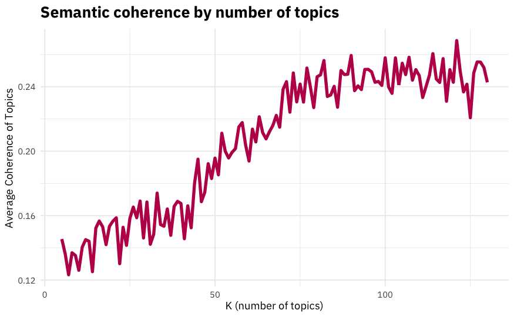

It seems that 121 topics give us the model with highest semantic coherence. Let’s get the results of that model and see what it gives us!

```r
many_models_lda %>%
  # filter(K <= 100) %>%
  slice_max(semantic_coherence) %>%
  pull(K) -> k

# get the output of the model with higest sematic coherence
model_121 <- many_models_lda %>%
  filter(K == k) %>%
  pull(topic_model) %>%
  .[[1]]

saveRDS(model_121, "model_121.rds")
rm(many_models_lda)
```

# Analyzing topic model results

As a first step to understanding LDA results, let’s get a summary table describing the topics LDA discovers.

```r
model_121 <- readRDS("model_121.rds")

# create summary of topics
SummarizeTopics(model_121)  -> model_121_sum

model_121_sum %>%
  arrange(-prevalence) %>%
  kbl(caption = "Summary of 90 topics", col.names = NULL) %>%
  kable_styling(bootstrap_options = c("striped", "hover", "responsive"), fixed_thead = T) %>%
  add_header_above(c("ID","topic","% of discourse","coherence","central terms \n high pr(term | topic)","specific terms \n high pr(topic | term)")) %>%
  scroll_box(width = "100%", height = "700px")
```

| ID | topic | % of discourse | coherence | central terms high pr(term \| topic) | specific terms high pr(topic \| term) |
| --- | --- | --- | --- | --- | --- |
| t_74 | social_network | 1.64 | 0.161 | network, social, individual, social_network, structural | individual, structural, social_network, network_position, network_connection |
| t_34 | men_women | 1.57 | 0.252 | women, network, men, gender, men_women | men, men_women, women, agentic_brokerage, expected_job |
| t_69 | creativity_assessment | 1.30 | 0.315 | idea, creativity, creative, creative_idea, assessment | assessment, creativity_assessment, experimental_study, creative_idea, creativity |
| t_81 | social_network | 1.27 | 0.131 | network, social, social_network, information, cognition | brain, cognition, circumstance, study_compare, argue |
| t_109 | social_capital | 1.15 | 0.343 | capital, social_capital, social, finding, access | capital, social_capital, access, positively, finding |
| t_73 | credit_attribution | 1.12 | 0.100 | credit, group, performance, show, work | credit, attribution_group, coauthor, find_investor, group_work |
| t_45 | chapter_review | 1.10 | 0.261 | literature, complexity, review, chapter, processe | complexity, chapter, temporal, literature, innovation_processe |
| t_28 | led_venture | 1.08 | 0.240 | venture, entrepreneur, find, led, finding | led, venture, impact_framing, led_venture, attribution |
| t_43 | perceived_creativity | 1.06 | 0.288 | creativity, experiment, creative, study, idea | experiment, thinking, target, evaluated, creative |
| t_61 | female_minority | 1.06 | 0.078 | network, social, people, labor_market, white | labor_market, white, minority_network, white_male, male_network |
| t_75 | social_network | 1.05 | 0.134 | research, future, organization, literature, draw | future, draw, conclude, future_research, identify |
| t_107 | social_network | 1.05 | 0.087 | people, network, perception, structure, show | network_structure, size_minority, structure_social, people, biased |
| t_10 | prior_experience | 1.04 | 0.364 | board, director, minority, prior, majority | board, director, prior_experience, majority, minority_director |
| t_37 | access_network | 1.03 | 0.143 | relationship, performance, employee, colleague, formal | relationship, colleague, instrumental, bank, diversity_information |
| t_51 | creative_idea | 1.03 | 0.186 | idea, creative, creative_idea, participant, condition | idea_selection, selected, participant, idea_creative, generation |
| t_90 | job_searching | 1.03 | 0.339 | gender, searching, job, job_searching, gap | searching, job_searching, based_job, gap_network, sector |
| t_84 | minority_group | 1.01 | 0.273 | social, critical, minority_group, size, minority | minority_group, critical, critical_mass, mass, convention |
| t_15 | complex_contagion | 1.00 | 0.512 | contagion, complex_contagion, complex, length, measure | complex_contagion, complex, contagion, length, path_length |
| t_77 | incremental_innovativeness | 0.98 | 0.724 | innovativeness, campaign, crowdfunder, incremental_innovativeness, radical_innovativeness | innovativeness, campaign, crowdfunder, incremental_innovativeness, radical_innovativeness |
| t_91 | creative_potential | 0.96 | 0.166 | potential, perceived, social, creative_potential, judgment | creative_potential, potential, judgment, screenwriter, social_judgment |
| t_119 | consumption_behavior | 0.96 | 0.205 | cultural, audience, market, typicality, consumption | cultural, typicality, consumption, computer_science, heterogeneous_audience |
| t_89 | social_network | 0.95 | 0.199 | actor, agency, relation, social_relation, leading_idea | actor, leading_idea, agency, social_relation, leading |
| t_56 | venture_capitalist | 0.93 | 0.222 | organization, market, label, appealing, venture_capitalist | label, appealing, venture_capitalist, ambiguous, capitalist |
| t_13 | social_capital | 0.92 | 0.176 | career, type, film, advancement, higher | film, advancement, career, type, career_advancement |
| t_115 | novelty_creativity | 0.92 | 0.271 | novelty, recognition, field, novelty_recognition, perspective | recognition, novelty, novelty_recognition, research_social, creative_target |
| t_20 | demand_side | 0.91 | 0.217 | gender, female, male, examine, evidence | female, female_entrepreneur, gender_bia, gender, male |
| t_3 | complex_contagion | 0.90 | 0.187 | ty, social, network, strength, homophilous | strength, ty, homophilous_ty, positional_resource, weak |
| t_36 | job_seeker | 0.90 | 0.298 | job, contact, cross, status, network | cross, job_seeker, seeker, job, race |
| t_108 | social_impact | 0.90 | 0.232 | social, impact, social_impact, warmth, female_led | social_impact, warmth, impact, female_led, sia |
| t_50 | evaluator_proposal | 0.89 | 0.403 | evaluation, proposal, evaluator, research, expertise | proposal, evaluator, evaluator_proposal, intellectual, intellectual_distance |

[output cut: 91 more lines]

Next, let’s see the 20 topics that are most prevalent in our corpus and create a graph for them.

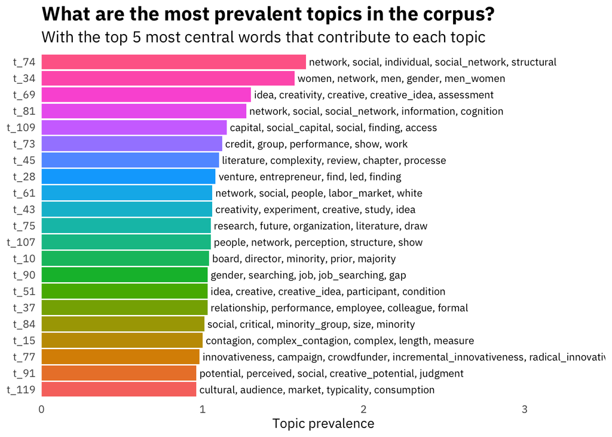

```r
model_121_sum %>%
  # get the 20 most prevalent topics
  slice_max(prevalence, n = 20) %>%
  # reorder the topics based on their prevalence
  mutate(topic = reorder(topic, prevalence)) %>%
  # create a graph with topic on the x axis, prevalence in the y axis,
  # add their most central terms as label, give each topic a different color
  ggplot(aes(x = topic,
             y = prevalence,
             label = top_terms_phi,
             fill = topic)) +
  # create a bar graph
  geom_col(show.legend = FALSE) +
  # horizontal alignment for text as bottom (0) so that the label will not overlap with bars
  geom_text(hjust = 0,
            # nudge label for y axis variable to create white space between label and bars
            nudge_y = 0.02,
            # change font type and font size of the label
            size = 3,
            family = "IBMPlexSans") +
  # flip x axis and y axis
  coord_flip() +
  # get rid of the space between bars and axis labels on y axis
  scale_y_continuous(expand = c(0,0),
                     # set limit for the y axis so that all the labels will appear
                     limits = c(0, 3.5)) +
  # change to theme tufte which strips graph of border, axis lines, and grids
  ggthemes::theme_tufte(base_family = "IBMPlexSans", ticks = FALSE) +
  # change font size of title and subtile
  theme(plot.title = element_text(size = 16, family="IBMPlexSans-Bold"),
        plot.subtitle = element_text(size = 13)) +
  # change text for axis and title and subtle
  labs(x = NULL, y = "Topic prevalence",
       title = "What are the most prevalent topics in the corpus?",
       subtitle = "With the top 5 most central words that contribute to each topic")
```

Let’s also see the most coherent topics in our corpus.

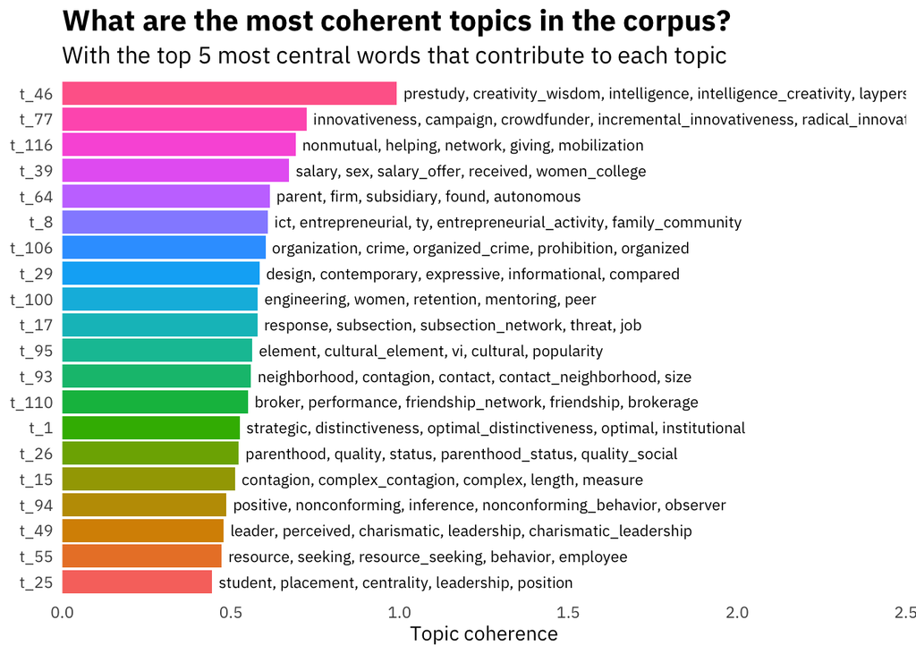

```r
model_121_sum %>%
  slice_max(coherence, n = 20) %>%
  mutate(topic = reorder(topic, coherence)) %>%
  ggplot(aes(x = topic,
             y = coherence,
             label = top_terms_phi,
             fill = topic)) +
  geom_col(show.legend = FALSE) +
  geom_text(hjust = 0,
            nudge_y = 0.02,
            size = 3,
            family = "IBMPlexSans") +
  coord_flip() +
  scale_y_continuous(expand = c(0,0),
                     limits = c(0, 2.5)) +
  ggthemes::theme_tufte(base_family = "IBMPlexSans", ticks = FALSE) +
  theme(plot.title = element_text(size = 16, family="IBMPlexSans-Bold"),
        plot.subtitle = element_text(size = 13)) +
  labs(x = NULL, y = "Topic coherence",
       title = "What are the most coherent topics in the corpus?",
       subtitle = "With the top 5 most central words that contribute to each topic")
```

Next, let’s create a scatterplot to see the relationship between topic coherence and prevalence.

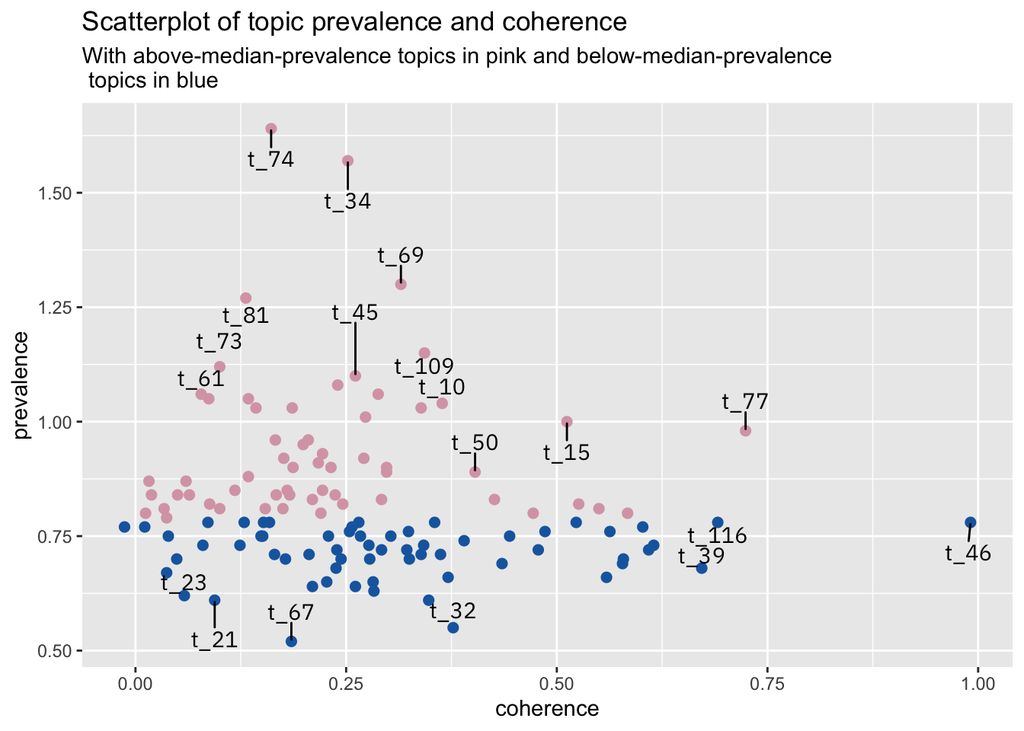

```r
model_121_sum %>%
  ggplot(aes(coherence, prevalence)) +
  geom_point(
    color = case_when(model_121_sum$prevalence > median(model_121_sum$prevalence) ~ "#d9a5b3",
                      TRUE ~ "#1868ae"),
    size = 2) +
  ggrepel::geom_text_repel(aes(label = topic),
                           family = "IBMPlexSans",
                           box.padding   = 0.7,
                           direction = "y") +
  labs(title = "Scatterplot of topic prevalence and coherence",
       subtitle = "With above-median-prevalence topics in pink and below-median-prevalence \n topics in blue")
```

# Detecting communities of topics

Next, let’s take a look at the relationship between our topics based on how frequent they cooccur in an abstract. One way to do this is to generate a dendrogram of topics. Here, topics closer to each other are more likely to be present in the same abstract than topics further apart form each other.

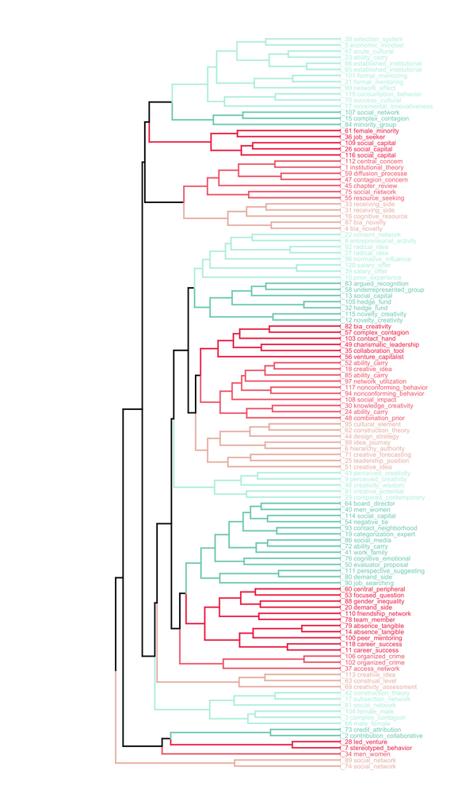

```r
# get topic prevalence in each paper
paper_topic <- as.data.frame(model_121$theta)

# get the data with paper id as rows and topic prevalence as colum
paper_topic[,1:ncol(paper_topic)-1] %>%
  # convert this dataframe into a matrix
  as.matrix() %>%
  # transpose the matrix so that paper id is now the columns and topic prevalence is now the rows
  t() %>%
  # calculate the Jensen Shannon distance between each topic's vectors of probability that it is present in the abstract of each of 103 papers (i.e., comparing topics based on its presence in the papers)
  philentropy::JSD() %>%
  # convert to a distance matrix
  as.dist() %>%
  # conduct hierarchical cluster analysis on the topics
  hclust(method = "ward.D") -> topic_clusters

# rename topic labels
topic_clusters$labels <- paste(model_121_sum$topic, model_121_sum$label_1)

topic_clusters %>%
  # convert to dendrogram
  as.dendrogram() %>%
  # set label color
  set("labels_col", value = c("#ecbdb1", "#f46e7b", "#f23955", "#7fd1c0", "#baf0e4",
                              "#ecbdb1", "#f46e7b", "#f23955", "#7fd1c0", "#baf0e4",
                              "#ecbdb1", "#f46e7b", "#f23955", "#7fd1c0", "#baf0e4",
                              "#ecbdb1", "#f46e7b", "#f23955", "#7fd1c0", "#baf0e4"), k=20) %>%
  # set label size
  set("labels_cex", 1) %>%
  # set branches color
  set("branches_k_color", value = c("#ecbdb1", "#f46e7b", "#f23955", "#7fd1c0", "#baf0e4",
                              "#ecbdb1", "#f46e7b", "#f23955", "#7fd1c0", "#baf0e4",
                              "#ecbdb1", "#f46e7b", "#f23955", "#7fd1c0", "#baf0e4",
                              "#ecbdb1", "#f46e7b", "#f23955", "#7fd1c0", "#baf0e4"), k = 20) %>%
  # set branches size
  set("branches_lwd", 1.5) %>%
  as.ggdend() %>%
  ggplot(horiz = T) +
  scale_y_reverse(expand = c(0.5, 0))
```